# Lab 10.2

## Learning Goals

*At the end of this exercise, you will be able to:*  
1. Build stacked bar plots of categorical variables.  
2. Build side-by-side barplots using `position= "dodge"`.

## Load the libraries

```r
library(tidyverse)
library(janitor)
library(palmerpenguins)
```

```r
options(scipen=999) #cancels the use of scientific notation for the session
```

## Data

**Database of vertebrate home range sizes.**  
Reference: Tamburello N, Cote IM, Dulvy NK (2015) Energy and the scaling of animal space use. The American Naturalist 186(2):196-211. http://dx.doi.org/10.1086/682070.  
Data: http://datadryad.org/resource/doi:10.5061/dryad.q5j65/1

```r
homerange <- read_csv("data/Tamburelloetal_HomeRangeDatabase.csv", na = c("", "NA", "\\")) %>% clean_names()
```

## Aesthetics

```r
p<- homerange%>%
  ggplot(aes(x=log10_mass, y=log10_hra))+
  geom_point()
```

Play with point size by adjusting the `size` argument.

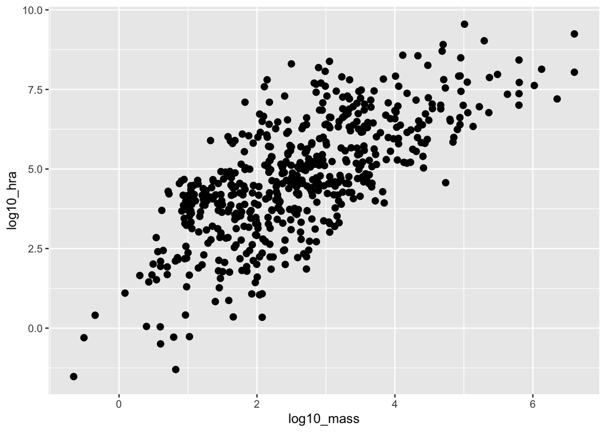

```r
p+geom_point(size=2.25)
```

We can color the points by a categorical variable.

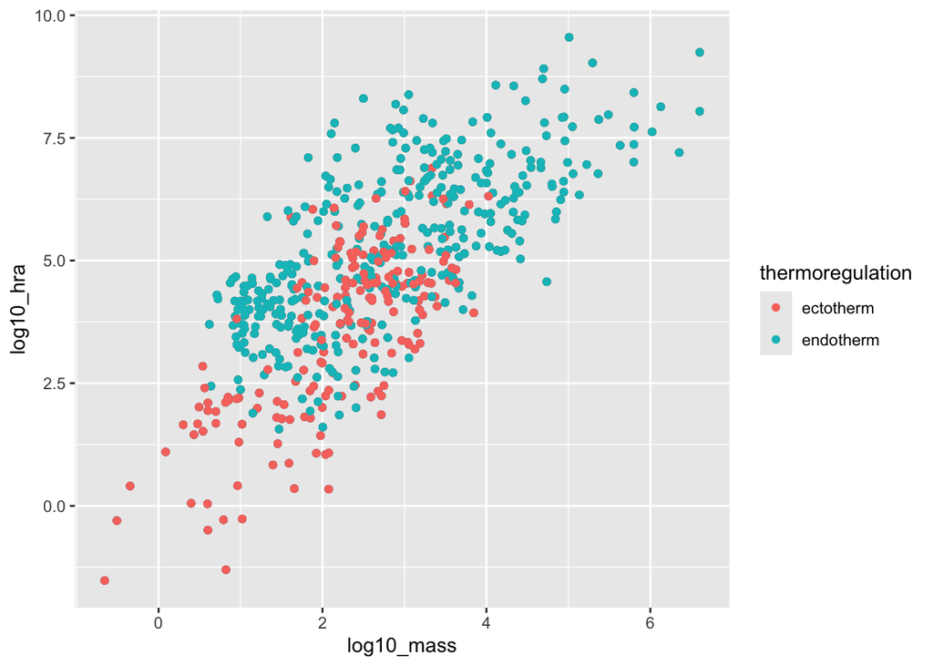

```r
p+geom_point(aes(color=thermoregulation))
```

We can also map shapes to another categorical variable.

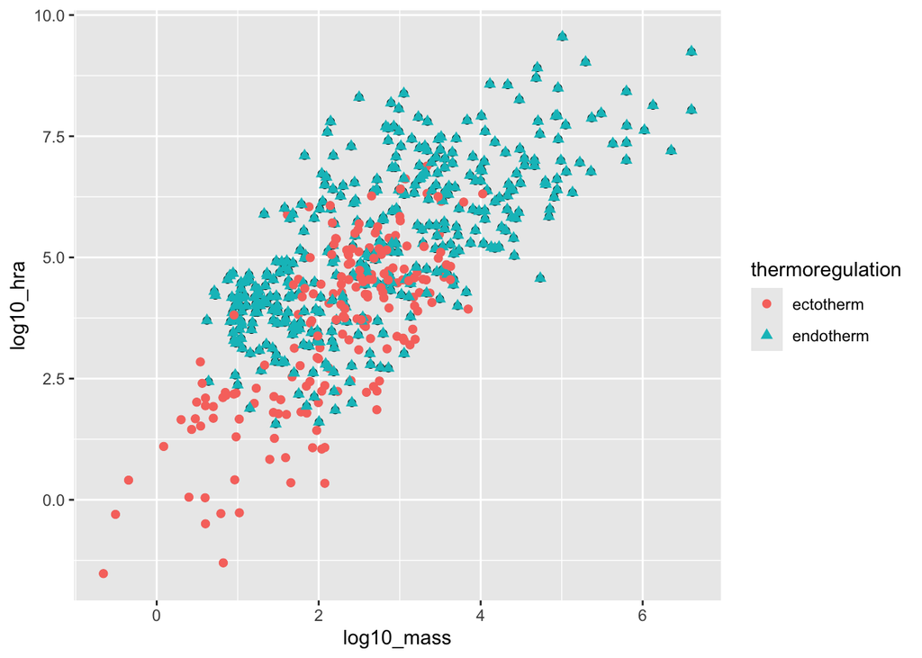

```r
p+geom_point(aes(shape=thermoregulation, color=thermoregulation), size=2)
```

What about just filling in with a color preference or size?

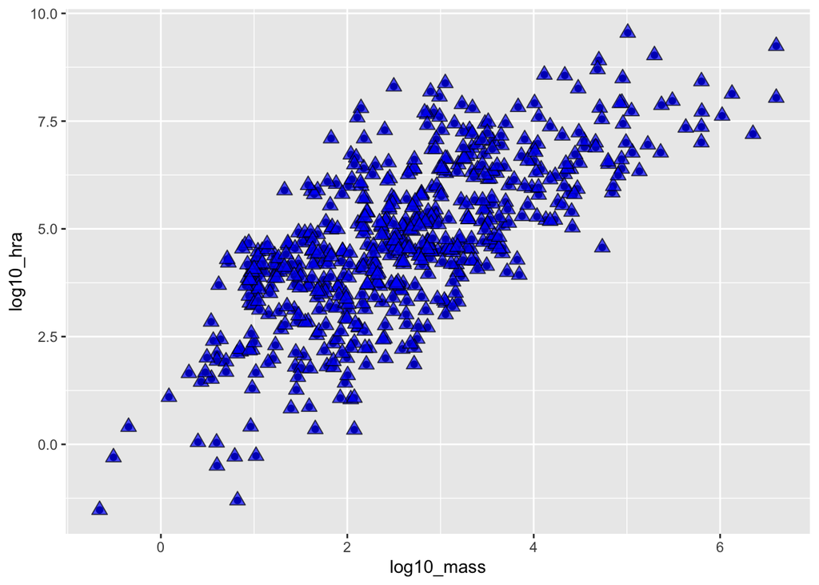

```r
p+geom_point(size=3, color="black", alpha=0.7, shape=24, fill="blue")
```

```r
colors()
```

```
##   [1] "white"                "aliceblue"            "antiquewhite"
##   [4] "antiquewhite1"        "antiquewhite2"        "antiquewhite3"
##   [7] "antiquewhite4"        "aquamarine"           "aquamarine1"
##  [10] "aquamarine2"          "aquamarine3"          "aquamarine4"
##  [13] "azure"                "azure1"               "azure2"
##  [16] "azure3"               "azure4"               "beige"
##  [19] "bisque"               "bisque1"              "bisque2"
##  [22] "bisque3"              "bisque4"              "black"
##  [25] "blanchedalmond"       "blue"                 "blue1"
##  [28] "blue2"                "blue3"                "blue4"
##  [31] "blueviolet"           "brown"                "brown1"
##  [34] "brown2"               "brown3"               "brown4"
##  [37] "burlywood"            "burlywood1"           "burlywood2"
##  [40] "burlywood3"           "burlywood4"           "cadetblue"
##  [43] "cadetblue1"           "cadetblue2"           "cadetblue3"
```

[output cut: 204 more lines]

```r
"cadetblue3"
```

```
## [1] "cadetblue3"
```

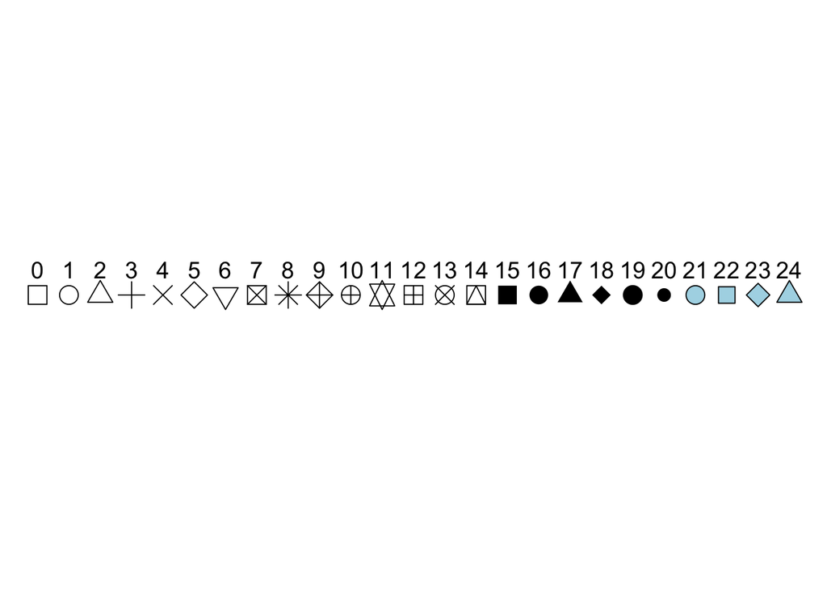

```r
# Plot all available point shapes
df <- data.frame(x = 1:25, y = rep(1, 25), shape = 0:24)

ggplot(df, aes(x, y)) +
  geom_point(aes(shape = factor(shape)), size = 5, fill = "lightblue") +
  scale_shape_manual(values = 0:24) +
  theme_void() +
  theme(legend.position = "none") +
  geom_text(aes(label = shape), vjust = -1, size = 5)
```

## Barplots and multiple variables

At this point you should be comfortable building bar plots that show counts of observations using `geom_bar()`. Last time we explored the `fill` option as a way to bring color to the plot; i.e. we filled by the same variable that we were plotting. What happens when we fill by a different categorical variable?

Let’s start by counting how many observations we have in each taxonomic group.

```r
homerange%>%
  count(taxon, sort=T)
```

```
## # A tibble: 9 × 2
##   taxon             n
##   <chr>         <int>
## 1 mammals         238
## 2 birds           140
## 3 marine fishes    90
## 4 snakes           41
## 5 river fishes     14
## 6 turtles          14
## 7 tortoises        12
## 8 lizards          11
## 9 lake fishes       9
```

Now let’s make a bar plot of these data.

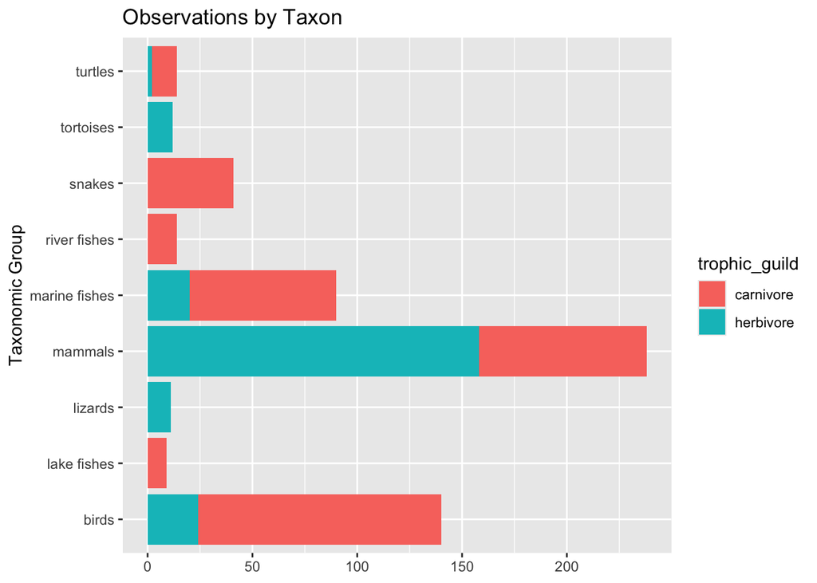

```r
homerange%>%
  ggplot(aes(x=taxon, fill=trophic_guild))+
  geom_bar()+
  coord_flip()+
  labs(title= "Observations by Taxon",
       x= "Taxonomic Group",
       y=NULL) #takes away the y axis label
```

By specifying `fill=trophic.guild` we build a stacked bar plot that shows the proportion of a given taxonomic group that is an herbivore or carnivore.

We can also have counts of each trophic guild within taxonomic group shown side-by-side by specifying `position="dodge"`.

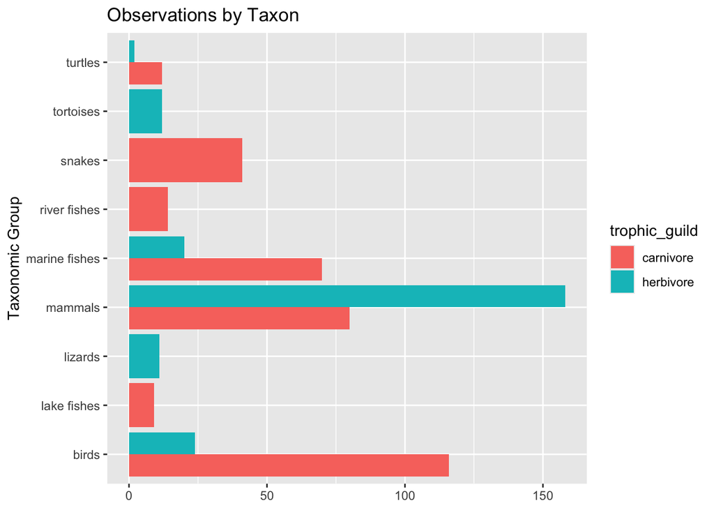

```r
homerange%>%
  ggplot(aes(x=taxon, fill=trophic_guild))+
  geom_bar(position="dodge")+
  coord_flip()+
  labs(title= "Observations by Taxon",
       x= "Taxonomic Group",
       y=NULL) #takes away the y axis label
```

Here is the same plot oriented vertically.

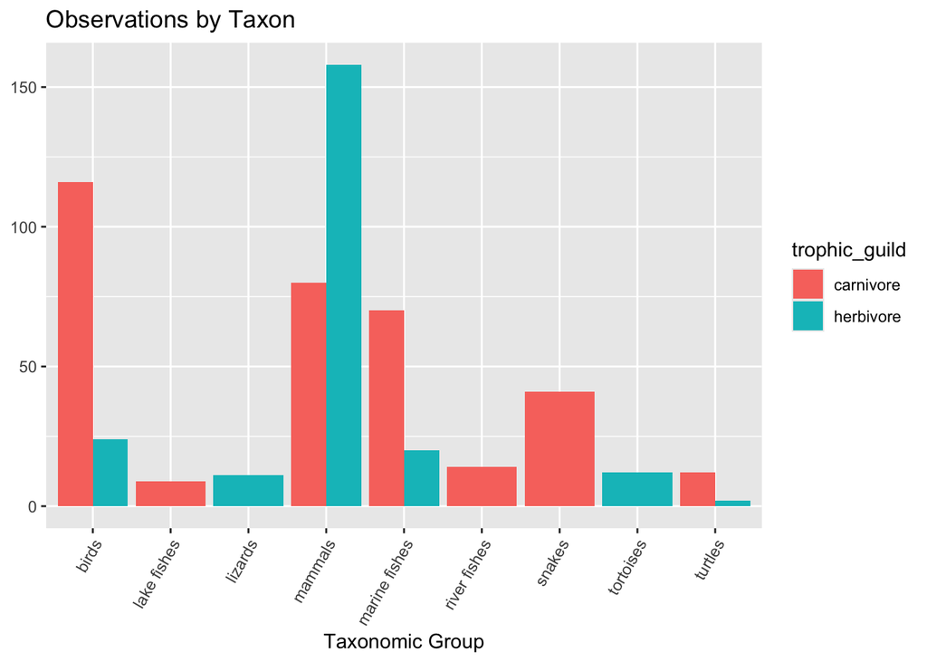

```r
homerange%>%
  ggplot(aes(x=taxon, fill=trophic_guild))+
  geom_bar(position="dodge")+
  theme(axis.text.x = element_text(angle=60, hjust=1))+
  labs(title= "Observations by Taxon",
       x= "Taxonomic Group",
       y=NULL) #takes away the y axis label
```

We can also scale all bars to a percentage.

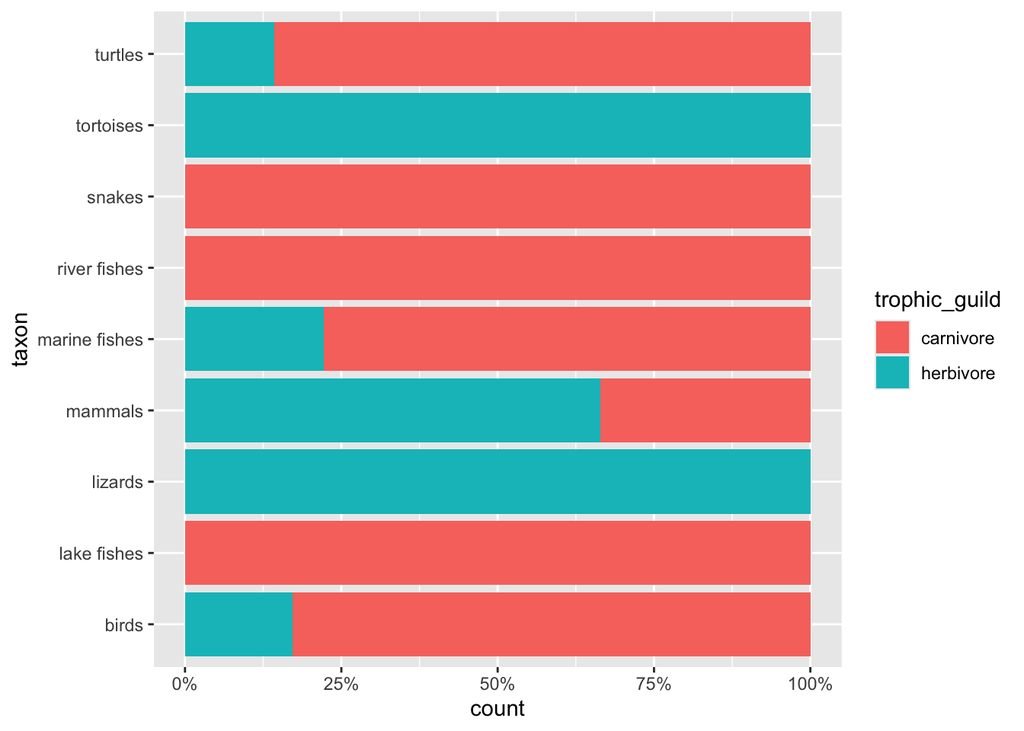

```r
homerange%>%
  ggplot(aes(x=taxon, fill=trophic_guild))+
  geom_bar(position=position_fill())+
  scale_y_continuous(labels=scales::percent)+
  coord_flip()
```

## Practice

For this practice, let’s use the [palmerpenguins](https://allisonhorst.github.io/palmerpenguins/articles/intro.html) data.

1. Make a bar plot that shows counts of individuals by island. Fill by species, and try both a stacked bar plot and `position="dodge"`.

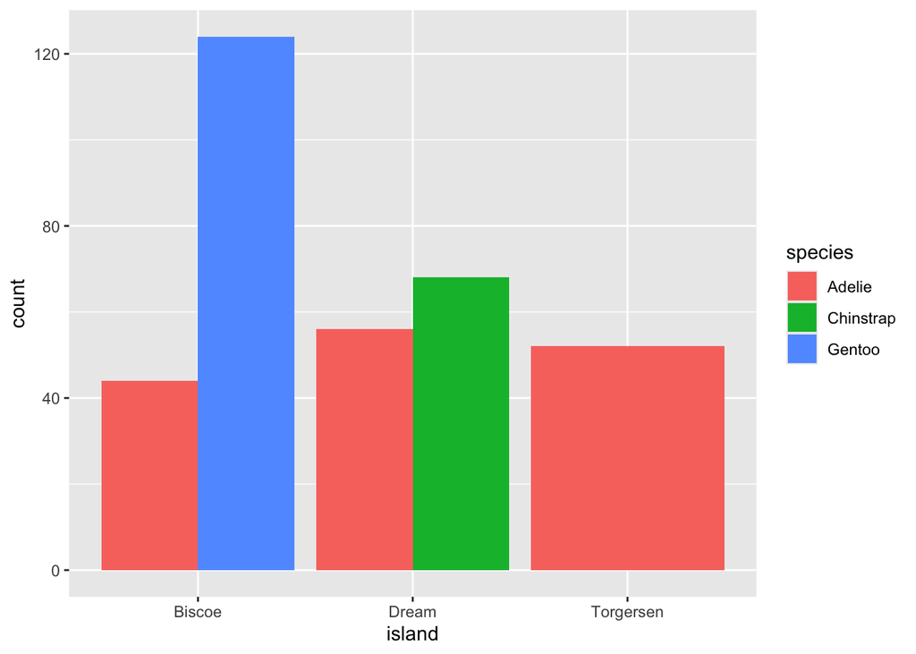

```r
penguins%>%
  #sort_by(island)+
  ggplot(aes(x=island, fill=species))+
  geom_bar(position="dodge")
```

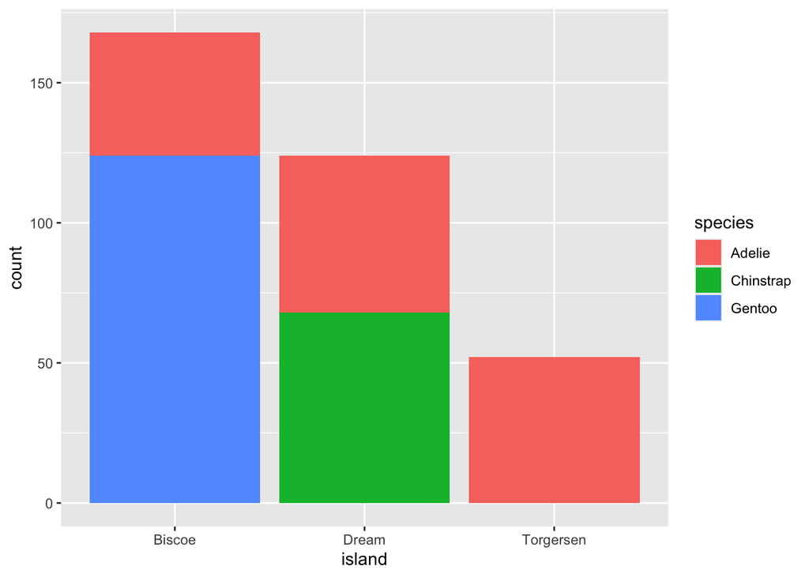

```r
penguins%>%
  #sort_by(island)+
  ggplot(aes(x=island, fill=species))+
  geom_bar()
```

2. Make another bar plot that shows the number of individuals by sex on each island?

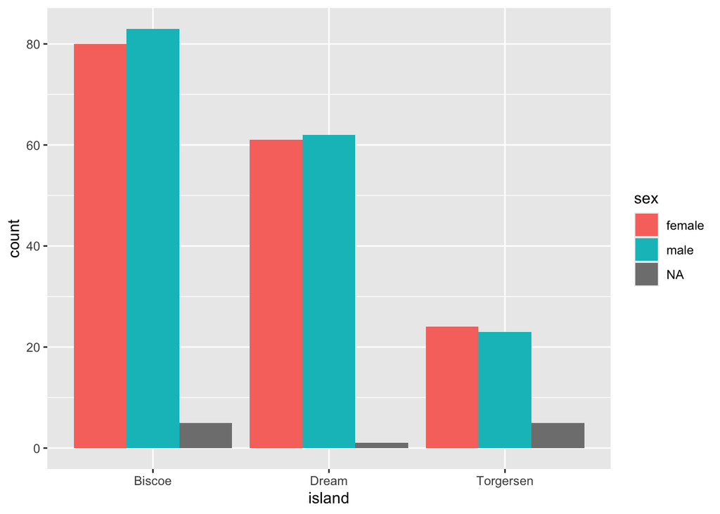

```r
penguins%>%
  ggplot(aes(x=island, fill=sex))+
  geom_bar(position="dodge")
```

## Using `group`

In addition to `fill`, `group` is an aesthetic that accomplishes the same function but does not add color. It groups data for plotting.

Here is a box plot that shows `log10.mass` by taxonomic `class.`

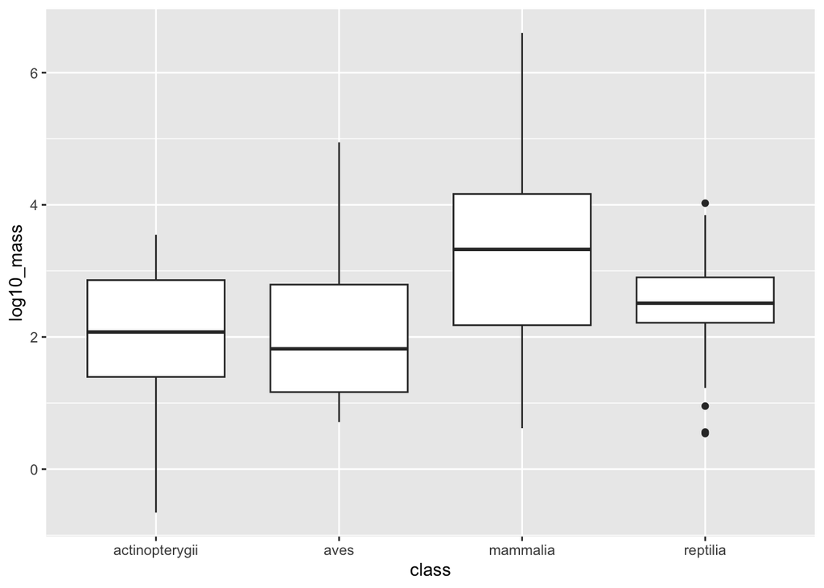

```r
homerange%>%
  ggplot(aes(x=class, y=log10_mass))+
  geom_boxplot()
```

I use `group` to make individual box plots for each taxon.

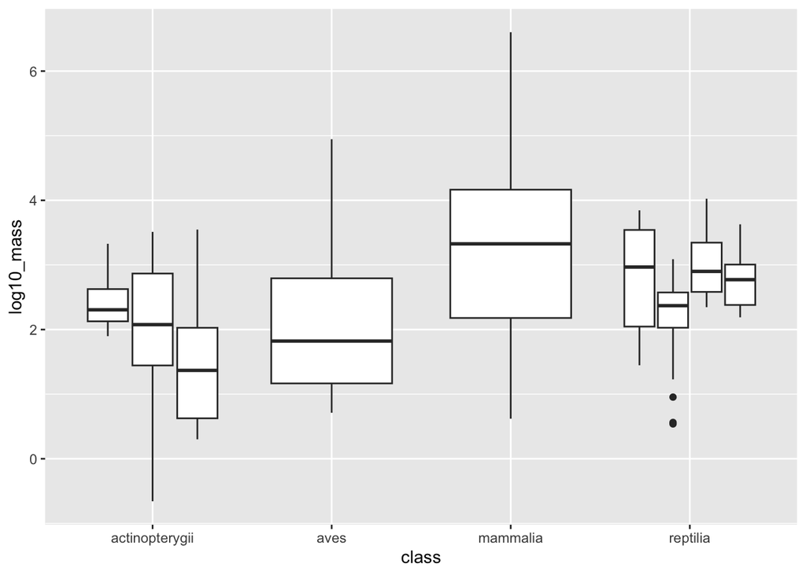

```r
homerange%>%
  ggplot(aes(x=class, y=log10_mass, group=taxon))+
  geom_boxplot()
```

I can also use `fill` to associate the different taxa with a color coded key.

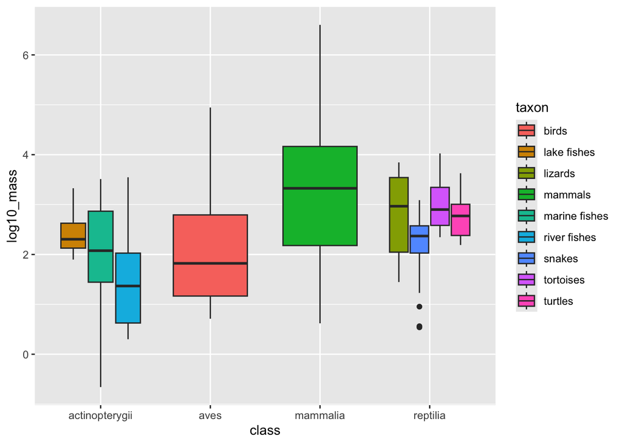

```r
homerange%>%
  ggplot(aes(x=class, y=log10_mass, fill=taxon))+
  geom_boxplot()
```

## Wrap-up

Please review the learning goals and be sure to use the code here as a reference when completing the homework.

–>[Home](https://jmledford3115.github.io/datascibiol/)